# ARIMA | U.S. Oil Production by Month

To forecast future oil production, we will apply the steps for ARIMA modeling. In the [Exploratory Data Analysis | Oil Production](https://mazuckerberg.georgetown.domains/DSAN_5600/5_EDA/5_oil_price_month.html) section, the raw data is transformed into a stationary time series through the application of first difference. The resulting ACF and PACF show the autocorrelation structure in the resulting time series.

### Autocorrelation Plots

**Plot**

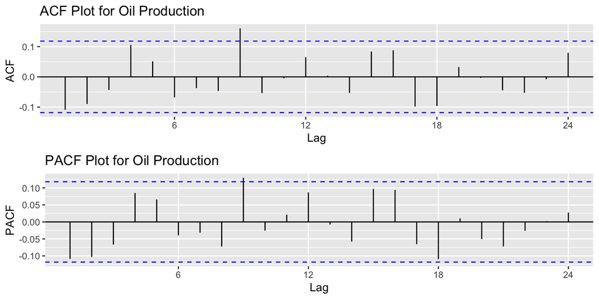

```r
# Import dataset
ts_oil_production <- read_csv('../data/ts_us_oil_production.csv')

# Create time series
ts_oil_production <- ts(ts_oil_production$x,star=decimal_date(as.Date("2000-01-15",format = "%Y-%m-%d")),frequency = 12)

# Resize plots
options(repr.plot.width = 5, repr.plot.height = 2)

# ACF Plot
acf_plot <- ggAcf(diff(ts_oil_production), main="ACF Plot for Oil Production")

# PACF Plot
pacf_plot <- ggPacf(diff(ts_oil_production), main="PACF Plot for Oil Production")

# Arrange Plots
grid.arrange(acf_plot, pacf_plot, nrow=2)
```

### Parameters Selection

$p=4$

$d=1$

$q=4$

To validate our choice, we used the auto.arima() function, which resulted in a model with parameters (0,1,2). This careful approach ensures that our ARIMA model is fine-tuned to recognize the patterns in the time series data.

**Parameters**

**Model Parameter Assesing**

```r
# Assigned time series to variable used in the algorithm
xt <- ts_oil_production

# PACF plot parameter selection
p_value <- 4

# Number of differences
d_value <- 2

# ACF plot parameter selection
q_value <- 4

# Initialize variable
i <- 1

# Initialize variable
temp <- data.frame()

# Calculate number of rows
rows <- p_value*d_value*q_value

#
ls <- matrix(rep(NA,6*rows),nrow=rows)

# Parameter testing loop
for (p in 1:p_value+1)
{
  for(q in 1:q_value+1)
  {
    for(d in 1:d_value)
    {

      #if(p-1+d+q-1<=8) #usual threshold
      #{

        model<- Arima(xt,order=c(p-1,d-1,q-1),include.drift=TRUE)
        ls[i,]= c(p-1,d-1,q-1,model$aic,model$bic,model$aicc)
        i=i+1
        #print(i)

      #}

    }
  }
}

temp <- as.data.frame(ls)

names(temp) <- c("p","d","q","AIC","BIC","AICc")

#temp
#knitr::kable(temp)
```

```
Minimum AIC:
```

```
   p d q      AIC     BIC     AICc
12 2 1 2 3844.739 3866.44 3845.052
```

```
Minimum BIC:
```

```
  p d q      AIC      BIC     AICc
2 1 1 1 3849.715 3864.182 3849.863
```

```
Minimum AICc:
```

```
   p d q      AIC     BIC     AICc
12 2 1 2 3844.739 3866.44 3845.052
```

**auto.arima()**

**auto.arima()**

```r
auto.arima(xt)
```

```
Series: xt
ARIMA(0,1,2) with drift

Coefficients:
          ma1      ma2    drift
      -0.1253  -0.0796  23.2551
s.e.   0.0596   0.0547  12.5326

sigma^2 = 68905:  log likelihood = -1920.53
AIC=3849.06   AICc=3849.21   BIC=3863.53
```

### Diagnostics

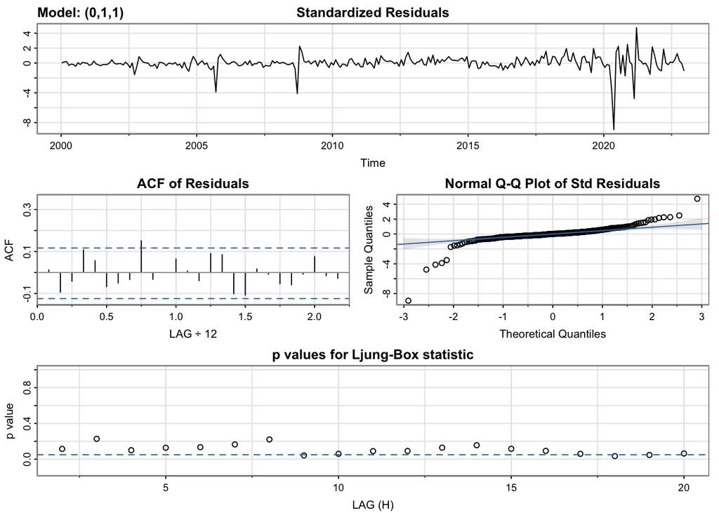

```r
p_autoarima <- 0
d_autoarima <- 1
q_autoarima <- 1

# Model diagnostics for best AIC
model_output <- capture.output(sarima(xt, p_autoarima, d_autoarima, q_autoarima))
```

**AIC**

**Model Diagnostics - parameters with best AIC**

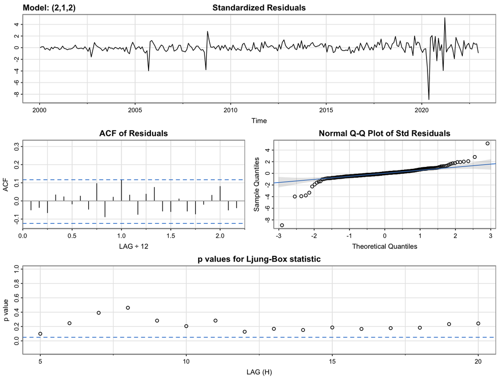

```r
AIC <- temp[which.min(temp$AIC),]

p1 <- AIC$p
d1 <- AIC$d
q1 <- AIC$q

# Model diagnostics for best AIC
model_output <- capture.output(sarima(xt, p1, d1, q1))
```

**BIC**

**Model Diagnostics - parameters with best BIC**

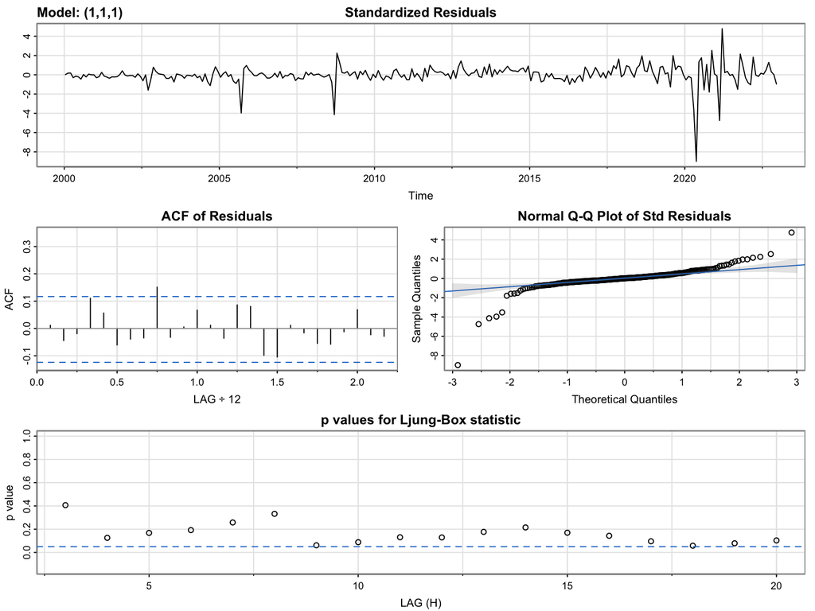

```r
BIC <- temp[which.min(temp$BIC),]

p2 <- BIC$p
d2 <- BIC$d
q2 <- BIC$q

# Model diagnostics for best BIC
model_output <- capture.output(sarima(xt, p2, d2, q2))
```

### Fit Model

Examining the fit line next to the original time series in the ARIMA model reveals a similarity, indicating a good fit. This visual coherence builds confidence in the model’s predictive power. It highlights the model’s ability to produce accurate forecasts.

**Model Fit Plot**

**Model Fitting**

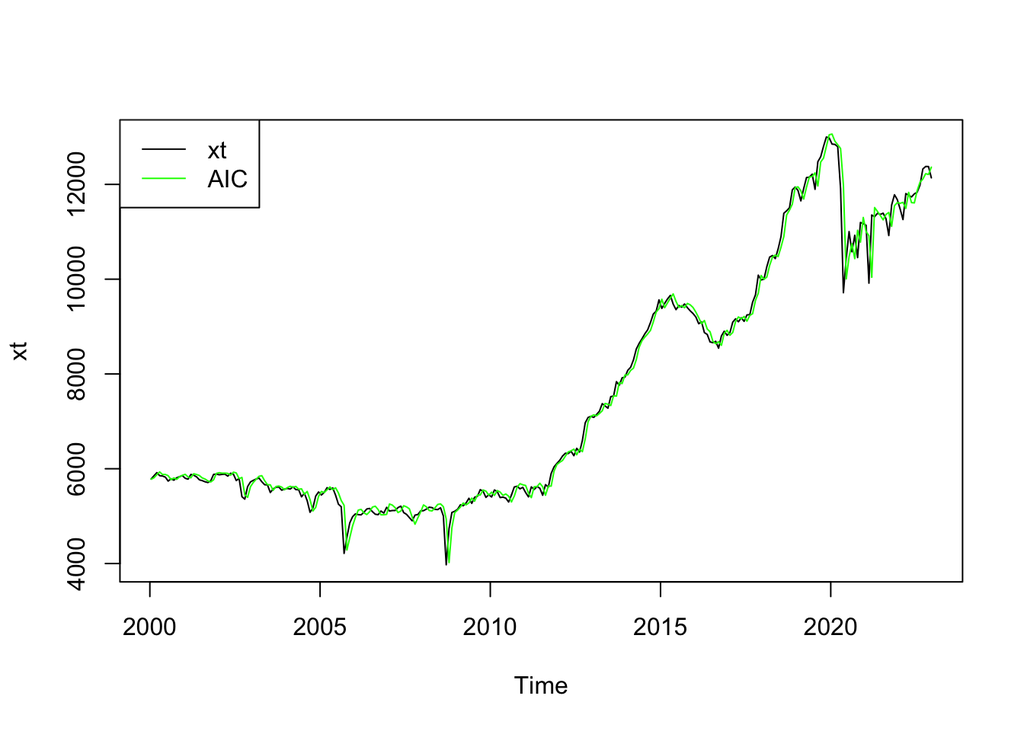

```r
best_model <- temp[which.min(temp$AIC),]

p <- best_model$p
d <- best_model$d
q <- best_model$q


model <- Arima(xt,order=c(p, d, q),include.drift = TRUE)

plot(xt, col="black")
lines(fitted(model), col="green")
legend(x = "topleft", legend = c("xt", "AIC"), col = c("black", "green"), lty = 1)
```

**Model Summary**

**Fitted Model Summary**

```r
fit <- Arima(xt, order=c(p, d, q))
summary(fit)
```

```
Series: xt
ARIMA(2,1,2)

Coefficients:
         ar1      ar2      ma1     ma2
      0.7524  -0.9471  -0.8441  0.9999
s.e.  0.0249   0.0232   0.0179  0.0312

sigma^2 = 66509:  log likelihood = -1917.65
AIC=3845.3   AICc=3845.52   BIC=3863.38

Training set error measures:
                   ME     RMSE      MAE      MPE     MAPE      MASE        ACF1
Training set 24.45833 255.5459 145.7703 0.224702 1.976277 0.2418375 -0.05091883
```

### Equation

$$\begin{align}
(1 - 0.7524B + 0.9471B^2)(1 - B)(X_t) &= (1 - 0.8441B + 0.9999B^2)(W_t) \\
\end{align}$$

### Forecast

The visual representation below shows the forecast of oil production, which shows modest fluctuations. When compared to benchmark models, our predictions are similar to the naive model, but there are notable differences when compared to the mean and seasonal naive models.

To improve forecasting accuracy, future iterations may include the exploration of advanced models such as VAR or ARIMAX, incorporating exogenous variables for deeper analysis.

**Forecast plot**

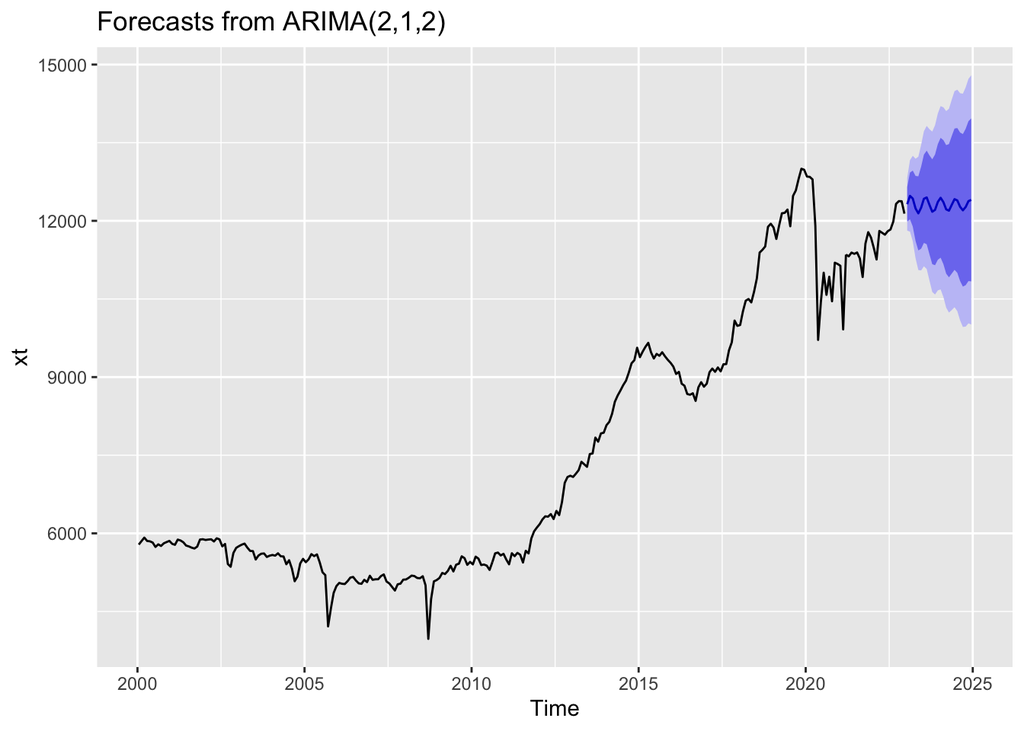

```r
forecast_fit <- forecast(fit,24)

# Plot
plot <- autoplot(forecast_fit)

# Show plot
plot
```

### Benchmark Models

**Benchmark Models Plot**

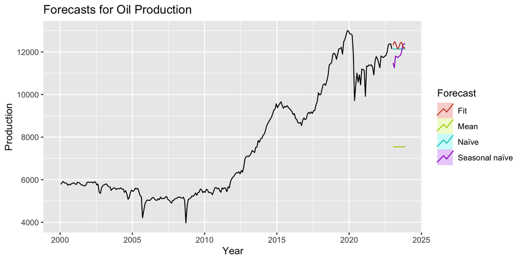

```r
autoplot(xt) +
  autolayer(meanf(xt, h=11),
            series="Mean", PI=FALSE) +
  autolayer(naive(xt, h=11),
            series="Naïve", PI=FALSE) +
  autolayer(snaive(xt, h=11),
            series="Seasonal naïve", PI=FALSE) +
  autolayer(forecast(forecast_fit, h=11),
            series="Fit", PI=FALSE) +
  ggtitle("Forecasts for Oil Production") +
  xlab("Year") + ylab("Production") +
  guides(colour=guide_legend(title="Forecast"))
```